# a3_task4_anastasia_kunz

Anastasia Kunz

11/1/2020

## Task 4

In this assignment, I will compare the mean size of purple urchins in the “control” and “annual” sections of the Naples Reef in January 2010.

```r
#read in data used in this task
urchin_data <- read.csv(here("data", "urchins.csv"))
```

## yay v and s are here

Select for purple urchins, January 2010 date, and Naples Reef site.

```r
# Only include Naples Reef observations for purple urchins in January 2010
purple_naples_2010 <- urchin_data %>%
  clean_names() %>%
  filter(common_name == "Purple Urchin") %>%
  mutate(date_converted = mdy(date)) %>%  #use lubridate to convert format
  mutate(year = year(date_converted)) %>% #create new year column (and month below)
  mutate(month = month(date_converted)) %>%
  filter(year == 2010, month == 1) %>%
  filter(site == "NAPL")
```

### Exploratory Data Visualization

Use histograms and QQ-plots to look at size distribution for annual and control treatments.

**Histogram**

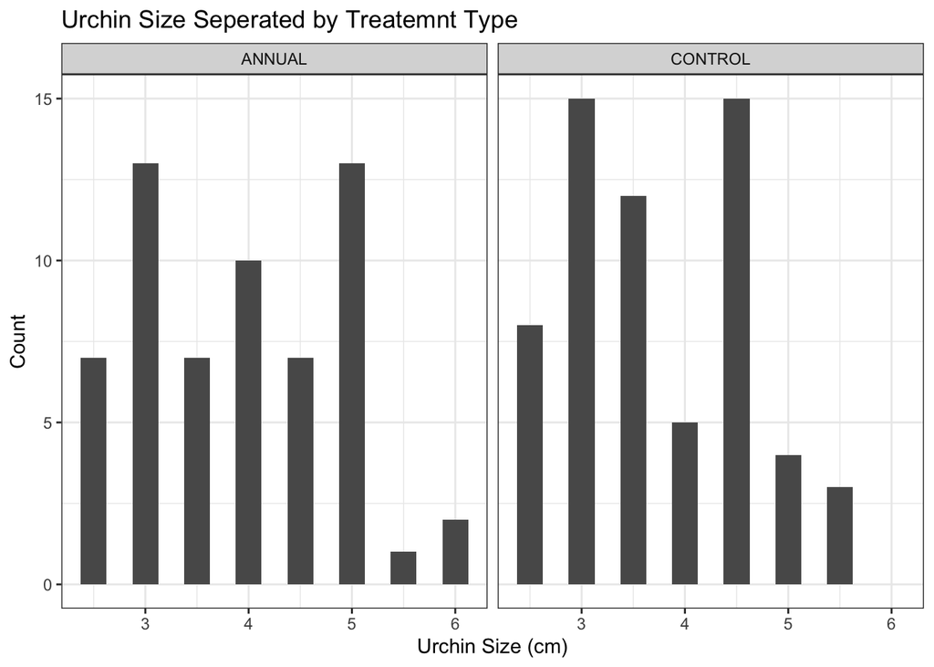

```r
ggplot(purple_naples_2010, aes(x = size))+ #plot selected data by size in histogram first
  geom_histogram(bins = 15)+
  facet_wrap(~ treatment)+ #separate graphs out by treatment for clarity
  theme_bw()+ #bw theme for clarity
  labs(
    x = "Urchin Size (cm)",
    y = "Count",
    title = "Urchin Size Seperated by Treatemnt Type"
  ) #update labels
```

**Quantile-Quantile Plot**

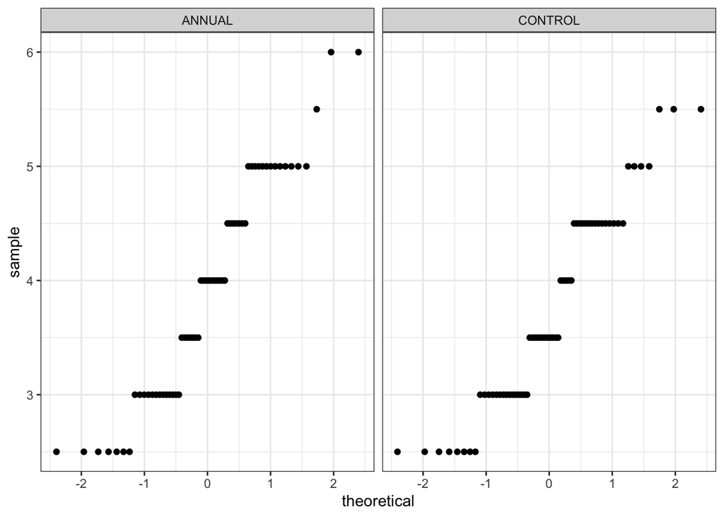

```r
ggplot(purple_naples_2010, aes(sample = size))+ #visualize quantile comparison of size
  geom_qq()+
  facet_wrap(~treatment)+ #again, break up by treatment type
  theme_bw()
```

**Main Takeaways from Exploratory Data Vis**

From looking at exploratory data visualizations we can see that the urchins in the annual treatment have a mean that is slightly higher than the urchins measured from the control treatment. Looking at the histogram for both treatments, it is interesting to see that there are two peaks in counts for urchin size, one around 3cm and one around 5cm for both populations, which is not captured by the descriptive statistics table below. It is also important to note the standard deviation for these populations. The annual treatment has a slightly higher standard deviation than the control treatment, but has a slightly smaller sample size. Judging from the proximity of the mean and median for both samples, together with the histogram and quantile-quantile plot, the samples look generally normal, which holds with the central limit theorem.

**Table of Descriptive statistics**

```r
purple_naples_2010_stats <- purple_naples_2010 %>%  #create new data set to call up for kable table below
  group_by(treatment) %>%  # compare the treatment types
  summarize(mean_size = mean(size), #calculate mean median and standard deviation for the treatments
            median_size = median(size),
            standard_dev = sd(size),
            sample_size  = n())

purple_naples_2010_stats %>% #create kable table of descriptive stats
  kable(col.names = c("Treatment",
                      "Mean (cm)",
                      "Median (cm)",
                      "Standard Deviation",
                      "Sample Size (n)"))%>%
  kable_styling(full_width = FALSE) #for visual clarity
```

| Treatment | Mean (cm) | Median (cm) | Standard Deviation | Sample Size (n) |
| --- | --- | --- | --- | --- |
| ANNUAL | 3.916667 | 4.0 | 0.9662380 | 60 |
| CONTROL | 3.725807 | 3.5 | 0.8668646 | 62 |

### Two Sample T-Test

First, split data frame into two, separated by treatment.

```r
annual_sample <- purple_naples_2010 %>%
  filter(treatment == "ANNUAL") %>%
  pull(size) #only need size values for the t-test

control_sample <- purple_naples_2010 %>%
  filter(treatment == "CONTROL") %>%
  pull(size)
```

Next, run two sample t-test.

```r
t.test(annual_sample, control_sample)
```

```
##
##  Welch Two Sample t-test
##
## data:  annual_sample and control_sample
## t = 1.1472, df = 117.66, p-value = 0.2536
## alternative hypothesis: true difference in means is not equal to 0
## 95 percent confidence interval:
##  -0.1386165  0.5203369
## sample estimates:
## mean of x mean of y
##  3.916667  3.725806
```

**T-Test Analysis**

Looking at the reported difference in means, we can see that they are relatively close together, with about a 0.2cm difference. When I calculate the percent increase from the control to the annual means, we can see that there is only about a 5% increase. Again, the standard deviation is also not very different for the two populations, both just a little less than 1. In this context, when we look at the p-value of 0.2536, it seems logical that we would *not* have overwhelming evidence to reject the null hypothesis. While the annual treatment urchins seem to be slightly bigger, there is not substantial evidence that their populations would likely have different means.

```r
#Percent increase from control to annual treatment:
(3.916667 - 3.725806)/3.725806
```

```
## [1] 0.05122677
```

**Conclusion**